# Final Project: Is Tokenization the next step for Global Financial Markets?

## Introduction

So a while ago I saw a video about blackrock ceo larry fink. For those who don’t know blackrock is the single largest asset management firm with about 10 trillion dollar asset under management. Just to give you an idea of how ridiculous that number is, that is triple the GDP(Gross Domestic Product) of the United Kingdom in 2023 ($3.34 trillion). So when someone who’s in charge of assets of that magnitude, it may be worth it to listen.

Fink went over tokenization, and its potential to shake the global financial industry. Tokenization is defined as the process using blockchain technology to create a digital representation of an asset that can be traded. This is extremely huge because it’s going to affect the speed at which we do business on a monstrous scale, because it will help make transactions near instantaneous and seamless. Why do I care if stocks get traded faster than they are now? Well because if you’re anything like me you were beating up strippers on GTA and watching power rangers instead of investing in bitcoin in 2011. Given where bitcoin and blockchain technology are compared to then, it’s wise to make better decisions this time around.

```python
import numpy as np
from datascience import *

# These lines do some fancy plotting magic.
import matplotlib
%matplotlib inline
import matplotlib.pyplot as plt

from sklearn.tree import DecisionTreeClassifier, plot_tree
from sklearn.neighbors import KNeighborsClassifier

from sklearn.metrics import confusion_matrix
from sklearn.metrics import accuracy_score, precision_score, recall_score, f1_score
```

## Data Description

```python
#Table for stock data including sector, market cap, and industry
stock_data = Table.read_table("sp500_companies.csv")
stock_data.show(5)
```

| Exchange | Symbol | Shortname | Longname | Sector | Industry | Currentprice | Marketcap | Ebitda | Revenuegrowth | City | State | Country | Fulltimeemployees | Longbusinesssummary | Weight |
| --- | --- | --- | --- | --- | --- | --- | --- | --- | --- | --- | --- | --- | --- | --- | --- |
| NMS | AAPL | Apple Inc. | Apple Inc. | Technology | Consumer Electronics | 248.13 | 3750683475968 | 1.34661e+11 | 0.061 | Cupertino | CA | United States | 164000 | Apple Inc. designs, manufactures, and markets smartphone ... | 0.0660299 |
| NMS | MSFT | Microsoft Corporation | Microsoft Corporation | Technology | Software - Infrastructure | 447.27 | 3325398614016 | 1.36552e+11 | 0.16 | Redmond | WA | United States | 228000 | Microsoft Corporation develops and supports software, se ... | 0.0585429 |
| NMS | NVDA | NVIDIA Corporation | NVIDIA Corporation | Technology | Semiconductors | 134.25 | 3287782522880 | 6.1184e+10 | 1.224 | Santa Clara | CA | United States | 29600 | NVIDIA Corporation provides graphics and compute and net ... | 0.0578807 |
| NMS | AMZN | Amazon.com, Inc. | Amazon.com, Inc. | Consumer Cyclical | Internet Retail | 227.46 | 2391742087168 | 1.11583e+11 | 0.11 | Seattle | WA | United States | 1.551e+06 | Amazon.com, Inc. engages in the retail sale of consumer ... | 0.0421061 |
| NMS | GOOGL | Alphabet Inc. | Alphabet Inc. | Communication Services | Internet Content & Information | 189.82 | 2332223602688 | 1.2347e+11 | 0.151 | Mountain View | CA | United States | 181269 | Alphabet Inc. offers various products and platforms in t ... | 0.0410583 |

... (498 rows omitted)

```python
#top stocks by marketing cap
stocks_by_market_cap = stock_data.sort("Marketcap", descending = True)
stocks_by_market_cap.show(5)
```

| Exchange | Symbol | Shortname | Longname | Sector | Industry | Currentprice | Marketcap | Ebitda | Revenuegrowth | City | State | Country | Fulltimeemployees | Longbusinesssummary | Weight |
| --- | --- | --- | --- | --- | --- | --- | --- | --- | --- | --- | --- | --- | --- | --- | --- |
| NMS | AAPL | Apple Inc. | Apple Inc. | Technology | Consumer Electronics | 248.13 | 3750683475968 | 1.34661e+11 | 0.061 | Cupertino | CA | United States | 164000 | Apple Inc. designs, manufactures, and markets smartphone ... | 0.0660299 |
| NMS | MSFT | Microsoft Corporation | Microsoft Corporation | Technology | Software - Infrastructure | 447.27 | 3325398614016 | 1.36552e+11 | 0.16 | Redmond | WA | United States | 228000 | Microsoft Corporation develops and supports software, se ... | 0.0585429 |
| NMS | NVDA | NVIDIA Corporation | NVIDIA Corporation | Technology | Semiconductors | 134.25 | 3287782522880 | 6.1184e+10 | 1.224 | Santa Clara | CA | United States | 29600 | NVIDIA Corporation provides graphics and compute and net ... | 0.0578807 |
| NMS | AMZN | Amazon.com, Inc. | Amazon.com, Inc. | Consumer Cyclical | Internet Retail | 227.46 | 2391742087168 | 1.11583e+11 | 0.11 | Seattle | WA | United States | 1.551e+06 | Amazon.com, Inc. engages in the retail sale of consumer ... | 0.0421061 |
| NMS | GOOGL | Alphabet Inc. | Alphabet Inc. | Communication Services | Internet Content & Information | 189.82 | 2332223602688 | 1.2347e+11 | 0.151 | Mountain View | CA | United States | 181269 | Alphabet Inc. offers various products and platforms in t ... | 0.0410583 |

... (498 rows omitted)

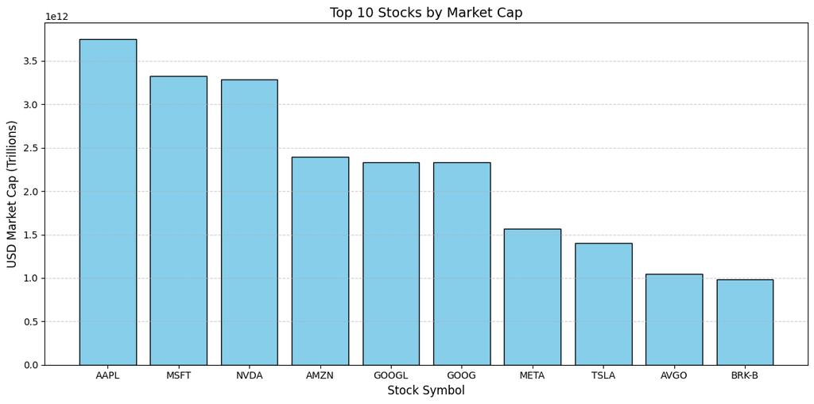

```python
symbols = stock_data.column('Symbol')  # Stock symbols
market_caps = stock_data.column('Marketcap')  # Market caps

# Sort by Marketcap and select top 10
sorted_indices = np.argsort(market_caps)[-10:][::-1]  # Get indices of top 10 stocks (descending order)
top_symbols = symbols[sorted_indices]  # Corresponding stock symbols
top_market_caps = market_caps[sorted_indices]  # Corresponding market caps

# Create a bar graph
plt.figure(figsize=(12, 6))
plt.bar(top_symbols, top_market_caps, color='skyblue', edgecolor='black')

# Add labels, title, and grid
plt.xlabel('Stock Symbol', fontsize=12)
plt.ylabel('USD Market Cap (Trillions)', fontsize=12)
plt.title('Top 10 Stocks by Market Cap', fontsize=14)
plt.grid(axis='y', linestyle='--', alpha=0.6)

# Display the plot
plt.tight_layout()
plt.show()
```

## Inference: Hypothesis Test or Confidence Interval

So given our data you're probably wondering if tokenized assets like bitcoin or companies heavily involved in that space like NVIDIA perform better than their counterparts.

```python
#Table for bitcoin price data including time, open/close and high/low price and volume (1 minute interval)
btc_data = Table.read_table("BTC-USD (20241216000000000 _ 20140930000000000).csv")

# Cleaning and converting 'Close' prices to floats by removing commas
close_prices_str = btc_data.column('Close')  # Extract as strings initially
close_prices_cleaned = [float(price.replace(',', '')) for price in close_prices_str]  # Remove commas and convert to float
btc_data = btc_data.with_column('Close', close_prices_cleaned)


close_prices = btc_data.column('Close')

# Calculate the mean closing price of the last 30 days
recent_period = close_prices[-30:]
# We use the mean of the last 30 days as the baseline
hypothesized_mean = np.mean(recent_period)

# Sample mean and standard deviation for the full dataset
sample_mean = np.mean(close_prices)
sample_std = np.std(close_prices)

n = len(close_prices)
t_statistic = (sample_mean - hypothesized_mean) / (sample_std / np.sqrt(n))
df = n - 1

# Calculating the two-tailed p-value using the cumulative distribution function of the t-distribution
p_value = 2 * (1 - stats.t.cdf(abs(t_statistic), df))

alpha = 0.05
if p_value < alpha:
    conclusion = "Reject the null hypothesis: The mean closing price of Bitcoin has significantly increased."
else:
    conclusion = "Fail to reject the null hypothesis: No significant increase in the mean closing price of Bitcoin."
print(f"T-statistic: {t_statistic}")
print(f"P-value: {p_value}")
print(conclusion)
```

```
T-statistic: -11.811490558390169
P-value: 0.0
Reject the null hypothesis: The mean closing price of Bitcoin has significantly increased.
```

For this section, I chose a one-sample t-test to evaluate whether the mean closing price of bitcoinovet the full dataset is significantly different from the mean clsoing price of the last days. The reason for using a t-test is because the population standard deviation is unknown to us and the dample size is large enough to justify the assumptions of the t-distribution. It's also appropriate because it allows for comparison between the hypothesized mean(last 30 days) and the observed sample mean(full dataset).

The large negative value of the t-statistic suggests a significant downward deviation from the hypothesized mean, meaning the Bitcoin price has increased significantly over time. A t-statistic of this magnitude shows that the observed difference is far beyond what we would expect by random chance.A p-value of 0.0 indicates that the observed difference is virtually impossible under the null hypothesis, providing strong evidence that Bitcoin's mean closing price has significantly increased. Considering how early bitcoin started vs where it is now, it is no secret that there is a significant demand for digital assets and the means to buy to them.

## Prediction

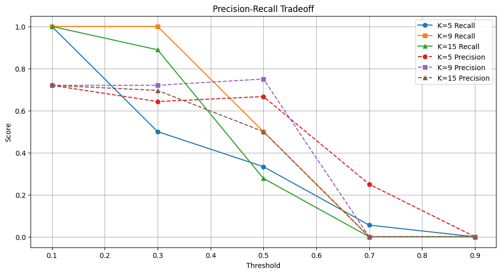

```
F1-Score for K=5 at threshold 0.5: 0.4444444444444444
```

```python
btc_data = Table.read_table("BTC-USD (20241216000000000 _ 20140930000000000).csv")

# Cleaning and converting to floats
close_prices_str = btc_data.column('Close')
close_prices_cleaned = [float(price.replace(',', '')) for price in close_prices_str]
btc_data = btc_data.with_column('Close', close_prices_cleaned)
volume_str = btc_data.column('Volume')
volume_cleaned = [float(vol.replace(',', '')) for vol in volume_str]
btc_data = btc_data.with_column('Volume', volume_cleaned)

price_change = np.diff(btc_data.column('Close'))
price_change = np.append(price_change, 0)  # Append 0 to match the length of the original table
btc_data = btc_data.with_column('Price Change', price_change)
btc_data = btc_data.with_column('Upward Movement', (btc_data.column('Price Change') > 0).astype(int))
features = btc_data.drop('Upward Movement').select('Close', 'Volume').to_array()
labels = btc_data.column('Upward Movement')

# Training and testing sets
split_index = int(len(features) * 0.8)
train_features = features[:split_index]
test_features = features[split_index:]
train_labels = labels[:split_index]
test_labels = labels[split_index:]


train_features = np.array([list(row) for row in train_features], dtype=np.float64)
test_features = np.array([list(row) for row in test_features], dtype=np.float64)

if train_features.ndim == 1:
    train_features = train_features.reshape(-1, 1)
if test_features.ndim == 1:
    test_features = test_features.reshape(-1, 1)


knn5 = KNeighborsClassifier(n_neighbors=5)
knn9 = KNeighborsClassifier(n_neighbors=9)
knn15 = KNeighborsClassifier(n_neighbors=15)
knn5.fit(train_features, train_labels)
knn9.fit(train_features, train_labels)
knn15.fit(train_features, train_labels)

# Evaluating the models
threshold_values = np.array([0.1, 0.3, 0.5, 0.7, 0.9])
knn5_recall, knn9_recall, knn15_recall = [], [], []
knn5_precision, knn9_precision, knn15_precision = [], [], []

for threshold in threshold_values:
    # Predictions for each threshold
    pred5 = knn5.predict_proba(test_features)[:, 1] > threshold
    pred9 = knn9.predict_proba(test_features)[:, 1] > threshold
    pred15 = knn15.predict_proba(test_features)[:, 1] > threshold

    # Calculating recall and precision with zero_division=0 to handle cases with no predicted samples
    knn5_recall.append(recall_score(test_labels, pred5, zero_division=0))
    knn9_recall.append(recall_score(test_labels, pred9, zero_division=0))
    knn15_recall.append(recall_score(test_labels, pred15, zero_division=0))

    knn5_precision.append(precision_score(test_labels, pred5, zero_division=0))
    knn9_precision.append(precision_score(test_labels, pred9, zero_division=0))
    knn15_precision.append(precision_score(test_labels, pred15, zero_division=0))

# Plotting precision-recall tradeoff
plt.figure(figsize=(12, 6))
plt.plot(threshold_values, knn5_recall, label="K=5 Recall", marker='o')
plt.plot(threshold_values, knn9_recall, label="K=9 Recall", marker='s')
plt.plot(threshold_values, knn15_recall, label="K=15 Recall", marker='^')

plt.plot(threshold_values, knn5_precision, label="K=5 Precision", linestyle='--', marker='o')
plt.plot(threshold_values, knn9_precision, label="K=9 Precision", linestyle='--', marker='s')
plt.plot(threshold_values, knn15_precision, label="K=15 Precision", linestyle='--', marker='^')

plt.title("Precision-Recall Tradeoff")
plt.xlabel("Threshold")
plt.ylabel("Score")
plt.legend()
plt.grid(True)
plt.show()
pred5_final = knn5.predict_proba(test_features)[:, 1] > 0.5
f1_knn5 = f1_score(test_labels, pred5_final, zero_division=0)
print(f"F1-Score for K=5 at threshold 0.5: {f1_knn5}")
```

In this prediction problem, the aim was to forecast the direction of Bitcoin's price movement using a K-Nearest Neighbors (KNN) model. The positive case was defined as any upward movement in the closing price, which we captured using the 'Upward Movement' feature (where 1 indicates an increase and 0 indicates no change or a decrease). By evaluating historical price and volume data, we aimed to build a predictive model to identify upward trends.

## Conclusion

Applying these insights to the real world, investors and financial institutions could employ advanced predictive models to enhance their trading strategies. By incorporating tokenized assets into their portfolios, they can benefit from the liquidity and efficiency that blockchain technology offers. Also, as we continue to improve our models and include more data points, the accuracy of such predictions will improve, making tokenization an even more compelling proposition for the future of global financial markets. The journey towards embracing tokenization starts with understanding and harnessing the power of digital assets, paving the way for a more dynamic and near-instantanoeous performing financial ecosystem.